# Coursework Report

*N* removed NAs: 2

*N* removed typo: 1

*N* removed <18: 13

*N* total clean: 135

| Group | *N* | *M*<sub>age</sub> | *M*<sub>rating</sub> |
| --- | --- | --- | --- |
| Control | 69 | 21.07 | 6.82 |
| Experim | 66 | 21.06 | 5.26 |

**Main analysis results**

*t*(133) = 10.7, *p* < .001

[interactive chart not shown]

[figure not shown]

[interactive chart not shown]

# Coursework Report

Analysing Data, Spring 2020

# Methods

## Participants

```
## # A tibble: 1 x 4
##    mean    sd   min   max
##   <dbl> <dbl> <dbl> <dbl>
## 1  21.1  2.25    18    28
```

```
## # A tibble: 2 x 5
##   condition     n  perc mean_age sd_age
##   <fct>     <int> <dbl>    <dbl>  <dbl>
## 1 white        69  51.1     21.1   2.33
## 2 red          66  48.9     21.1   2.18
```

## Design

The conceptual hypothesis for this experiment is whether colour influences perceived attractiveness? The independent variable in the study is the colour in each condition, in the experimental condition the colour of the frame is red and in the control condition the colour of the frame is white, this factor is the predictor because it is being changed. Whereas the outcome is the rating, perceived attractiveness this was calculated by the participants answering 3 face-valid questions on attractiveness and rating the answers on a 9 point scale. The higher the ratings on the scale meant the higher the participant’s perceived attractiveness of the male in the photo. Therefore, the operational hypothesis, is that the participants in the experimental condition (red frame) will rate the males attractiveness higher on the 9-point scale compared to those in the control condition (white frame). In order to test this the statistical analysis that will be used is a two-sample t-test.

# Results

The results were calculated by creating a composite score, for attractiveness. This composite score was calculated by combining the mean ratings of all 3 questions together for each condition, which led to an overall attractiveness score for the red condition and the white condition, these scores allow us to compare the attractiveness ratings in both conditions. Participants ratings for perceived attractiveness, showed that there was a higher mean in the white condition (6.82) compared to the red condition (5.26). This suggests that the hypothesis may not be true, because it shows that participants in the control condition had higher perceived attractiveness ratings, which goes against the support of the red effect. These results can be seen in table 3.

```
## # A tibble: 2 x 5
##   condition     n  perc mean_score sd_score
##   <fct>     <int> <dbl>      <dbl>    <dbl>
## 1 white        69  51.1       6.82    0.777
## 2 red          66  48.9       5.26    0.909
```

```
##
##  Two Sample t-test
##
## data:  attractiveness_comp by condition
## t = 10.696, df = 133, p-value < 0.00000000000000022
## alternative hypothesis: true difference in means is not equal to 0
## 95 percent confidence interval:
##  1.266465 1.841133
## sample estimates:
## mean in group white   mean in group red
##            6.816425            5.262626
```

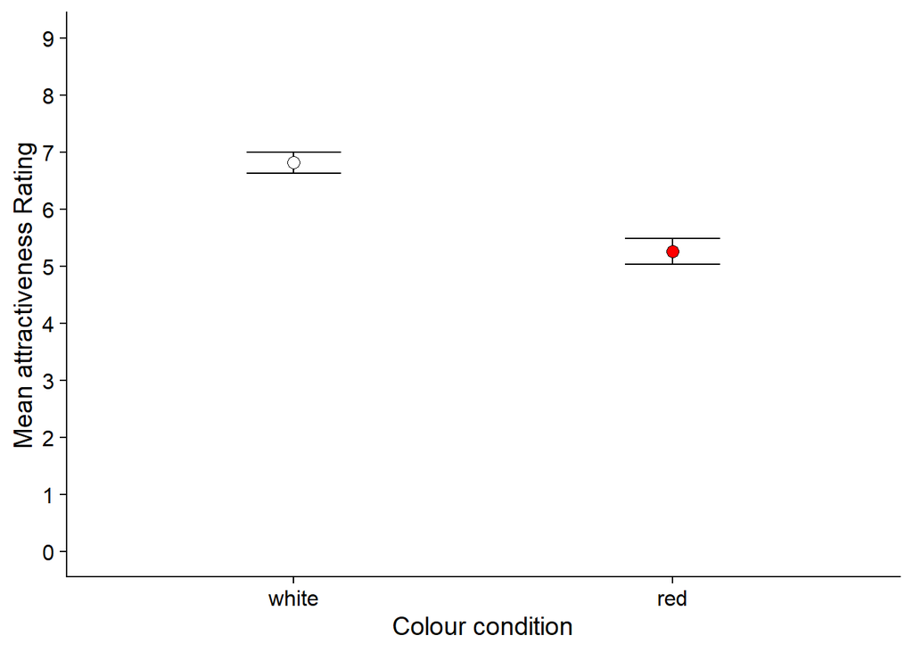

# Discussion

This experiment was set out to further investigate the red effect; whether the colour red influenced perceived attractiveness. The results showed that those in the control condition, who viewed the white frame around a photo of a moderately attractive man rated a higher overall attractiveness of 6.82, compared to the experimental condition who viewed the same picture but surrounded by a red frame, of 5.26. These results differ from Elliot’s 2010 original study, as he found that ‘participants in the red condition, compared to those in the white condition rated the target man as more attractive (M= 6.70, SD = 1.00, and M= 5.67, SD= 0.91).’ The findings from Elliot’s (2010) study differ extremely from the findings found in this experiment, this is because Elliot’s original study (2010) showed support for the influence of red on attractiveness, with participants in the red condition rating the man as more attractive. Whereas this experiment does not support the influence of red on attractiveness ratings, as shown by the graph participants in the control condition in fact had higher attractiveness ratings than those in the red. This means it questions the red effect as the results are very different, meaning that more research around the area needs to be done, in order to come to a conclusion about the validity of the red effect, and whether it may not be significant. There have however, been other studies that have also investigated the red effect, by doing replications and modifications of Elliot’s original study in 2010. There are a number of studies that like Elliot’s study in 2010, show support for the red effect, therefore largely differ from the results found in this study, which did not show support for the red effect. Roberts, Owen and Havlicek (2010) also found that in all 3 of their experiments, that those who were viewed as wearing a red shirt increased women’s attractiveness rating of men. There has also be support for the red effect in culturally isolated towns, ‘results indicate that the red attraction link observed in the US and Europe is also present in culturally isolated individuals.’ (Elliot, Tracy, Pazda, Beall, 2013) However, there are also many studies that have similar results to this study, whereby they don’t show significant support for the theory that red has a positive effect on attractiveness. In 2013, Francis replicated Elliot’s original study but on a much larger sample, they found that women in the red condition rated higher attractiveness compared to the control group, however it ‘fell short of statistical significance’ and was ‘not as strong as those in the smaller samples.’ Another study that found no support for the red effect, was conducted by Hesslinger, Goldbach and Carbon (2015), but instead they did find ‘a significant effect of apparel style with attractiveness ratings being higher for men wearing formal apparel than for men wearing casual apparel.’ The varying support and challenges towards the significance of the red effect, again questions how robust the link is between the colour red and increasing attractiveness.

The strengths of this study could be said to show support for the argument that there’s a limited link between the colour red and attractiveness. The study was highly controlled, making it easy to replicate and due to the high control, it is easier to establish a cause and effect relationship. Also, like Elliot’s original study (2010) the participants were not aware of the true aim of the study, which meant there was limited chance for bias to inflict the results. However, as seen above there are many studies with conflicting results, which shows its hard to come to a conclusion on how significant the red effect is. There are also, limitations of this study, such as the sample is relatively small, which can have a negative impact on the generalisability of the results, because as seen in Francis’ study (2013) as the sample size increases the significance of the red effect changes. The task of rating someone’s attractiveness solely on looking at a picture with a different colour frame, is very unrealistic, meaning it lack ecological validity. The study also does not take into account various other factors such as individual preferences or materialistic factors like certain clothing being worn. This is another reason why there could be a lack of validity in the study because personal preference could have been an underlying factor that influenced the attractiveness rating. Due to the varying results across many studies this research question is still worth investigating because there are still many questions raised about the effect of the colour red on perceived attractiveness. In order to do this further research, experiments should investigate the effect by looking at more than just pictures with a different colour frame, background or shirt. Instead various other factors should be taken into account creating different conditions, meaning comparing between conditions can be more valid and a cause and effect relationship can be established.

Overall the results from the study showed that the participants in the white condition rated higher perceived attractiveness compared to those in the red condition, as mentioned before this can be seen in table 3, (M= 6.82, SD= 0.78, M=5.26, SD= 0.91). These results differ from Elliot’s original study (2010) where he found that those in the red condition rated higher attractiveness ratings compared to those in the control condition, (M= 6.70, SD= 1.00, M= 5.67, SD= 1.34). The various support and against studies investigating the red effect shows that the link between red and attractiveness may not be as clear as originally thought in Elliot’s 2010 study. Therefore, further research needs to be don’t in order to figure out the true significance of the red effect.

# References

Elliot, A. J., Niesta Kayser, D., Greitemeyer, T., Lichtenfeld, S., Gramzow, R. H., Maier, M. A., & Liu, H. (2010). Red, rank, and romance in women viewing men. Journal of Experimental Psychology: General, 139(3), 399.

Elliot, A. J., Tracy, J. L., Pazda, A. D., & Beall, A. T. (2013). Red enhances women’s attractiveness to men: First evidence suggesting universality. Journal of Experimental Social Psychology, 49(1), 165-168.

Francis, G. (2013). Publication bias in “Red, rank, and romance in women viewing men,” by Elliot et al.(2010).

Peperkoorn, L. S., Roberts, S. C., & Pollet, T. V. (2016). Revisiting the red effect on attractiveness and sexual receptivity: No effect of the color red on human mate preferences. Evolutionary Psychology, 14(4), 1474704916673841.

Roberts, S. C., Owen, R. C., & Havlicek, J. (2010). Distinguishing between perceiver and wearer effects in clothing color-associated attributions. Evolutionary Psychology, 8(3), 147470491000800304.

Hesslinger, V. M., Goldbach, L., & Carbon, C. C. (2015). Men in red: A reexamination of the red-attractiveness effect. Psychonomic bulletin & review, 22(4), 1142-1148.